# MiniProject2

Author

Grace Rubio, Oyinda Sanni, Mia Mason

## Libraries and data load

Put whatever libraries you use here.

Load your data here

```r
# Data Compiled in separate QMD (Submitted in an earlier assignment)
FullData_2025 <- read.csv("Data/FullData_2025.csv")
```

```r
# Clean Data [Helpful for graphs and Models]
FullData_2025 <- FullData_2025|>
  drop_na()

# Make response variable a Factor [Helpful for LOGISTIC REG]
FullData_2025<-FullData_2025|>
  mutate(Democracy=as.factor(Democracy))
```

**NOTE REGARDING DATA:** Please note that the data for each variable was collected from the last year provided in their respective datasets. For our purposes, we will be treated all variables as being collected from the year 2025 regardless of their most recent data. Below are the *actual* years each column was collected from:

*Democracy:* 2020

*CO2 Emissions:* 2022

*GDP per Capita:* 2025

*Human Development Index:* 2023

*People in Poverty:* 2025

*Gapminder Regions:* 2025

## Exploratory data analysis

For this section graph and find statistics for each of your predictor variables vs the response. You do not need to look at the predictor variables individually

## Variable 1: CO2 Emissions

### Graph and description

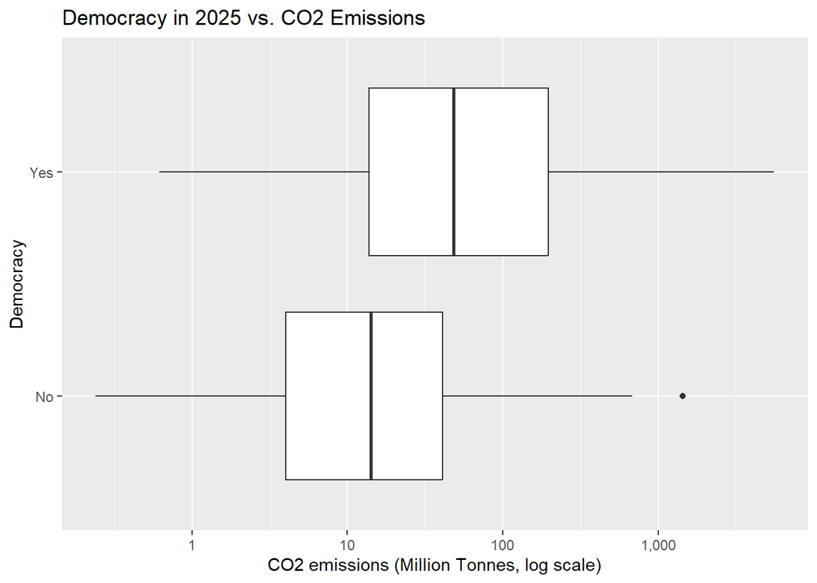

```r
#PLOT
FullData_2025 |>
  ggplot(aes(x = CO2, y = Democracy)) +
  geom_boxplot() +
  scale_x_log10(labels = scales::comma) +# using log because you cant see the data regularly
  labs(x = "CO2 emissions (Million Tonnes, log scale)",
       y = "Democracy",
       title = "Democracy in 2025 vs. CO2 Emissions")
```

This boxplot compares CO2 emissions, in million tonnes, for democracies and non-democracies. The x axis is on a log scale, so each step to the right is 10 times bigger. The democracy box is farther to the right. The median is about 48 for democracies and about 14 for non-democracies. The middle half of democracies goes from about 14 to 200. For non-democracies, it goes from about 4 to 42. The boxes overlap a lot, so many countries in both groups have similar emissions. Still, the typical democracy emits more, and democracies are more spread out. Their whiskers go from about 0.6 up to about 5,500, and the USA is at the far end. Non-democracies go from about 0.2 up to about 700. They have one outlier at about 1,440, which is Russia. The log scale makes the biggest values look smaller than they are, so the table shows the real numbers. Overall, democracies tend to emit more CO2, but the two groups overlap a lot.The groups overlap a lot, so CO2 would not predict democracy well by itself.

### Stats and description

```r
Democracy_CO2_summary <- FullData_2025 |>
  group_by(Democracy) |>
  summarize(avg_co2 = mean(CO2 ),
            sd_co2 = sd(CO2),
            min_co2 = min(CO2),
            max_co2 = max(CO2),
            mdn_co2 = median(CO2),
            iqr_co2 = IQR(CO2),
            count = n())

Democracy_CO2_summary
```

```
# A tibble: 2 × 8
  Democracy avg_co2 sd_co2 min_co2 max_co2 mdn_co2 iqr_co2 count
  <fct>       <dbl>  <dbl>   <dbl>   <dbl>   <dbl>   <dbl> <int>
1 No           73.4   193.   0.24    1443.    14.1    37.0    85
2 Yes         256.    729.   0.618   5564.    48.4   184.     73
```

```r
FullData_2025 |># to find more information on the data
  arrange(desc(CO2)) |>
  select(name, Democracy, CO2) |>
  head(8)
```

```
          name Democracy      CO2
1          USA       Yes 5563.688
2        India       Yes 2655.606
3       Russia        No 1442.518
4        Japan       Yes 1238.459
5      Germany       Yes  775.354
6  South Korea       Yes  700.960
7         Iran        No  679.487
8 Saudi Arabia        No  670.843
```

This table shows CO2 emissions, in million tonnes, for 73 democracies and 85 non-democracies. Democracies emit more. Their mean is about 256.2, and the mean for non-democracies is about 73.4. The medians show the same thing, at about 48.4 for democracies and about 14.1 for non-democracies. In both groups, the mean is about five times bigger than the median. This means a few very big emitters pull the means up, so the median shows a typical country better. Democracies are also more spread out. Their standard deviation is about 729.3 and their IQR is about 183.6. For non-democracies, these are about 193.2 and 37.0. The smallest values are tiny in both groups, about 0.6 for democracies and about 0.2 for non-democracies. The biggest values are very different. The top democracy is the USA at about 5,563.7. The top non-democracy is Russia at about 1,442.5. China is missing from the data, so the non-democracy numbers are probably too low. Overall, democracies tend to emit more CO2 and vary more, but this shows a link, not a cause.

## Variable 2: GDP per Capita

### Graph and description

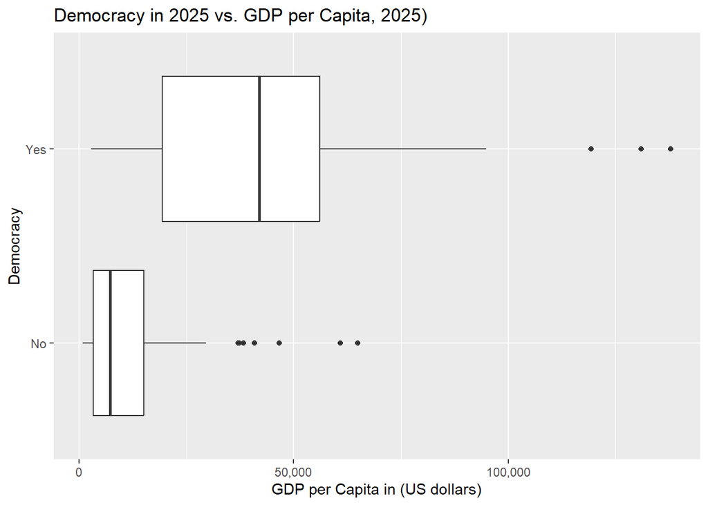

```r
FullData_2025|>
  ggplot(aes(x = GDP, y = Democracy)) +
  geom_boxplot() +
  scale_x_continuous(labels = scales::comma)+ # removes the statistical notation in the x axis
  labs(x = "GDP per Capita in (US dollars)",
       y = "Democracy",
       title = "Democracy in 2025 vs. GDP per Capita, 2025)")
```

This boxplot compares GDP per capita, in US dollars, for democracies and non-democracies. The democracy box is far to the right of the non-democracy box. The median is about 42,000 for democracies and about 7,000 for non-democracies. The middle half of democracies goes from about 19,000 to 56,000. For non-democracies, it goes from about 3,000 to 15,000. The two boxes barely overlap, so most democracies are richer per person than most non-democracies. Democracies are also more spread out, because their box is much wider. Both groups have outliers on the high end. Democracies have three, from about 120,000 to 138,000. Non-democracies have six, from about 37,000 to 65,000. Some of these non-democracies are richer than the typical democracy. The non-democracy group is more skewed to the right, with most countries bunched on the left and a few rich ones far out. Overall, democracies tend to have a much higher GDP per capita. The boxes barely overlap, so GDP separates the groups well, but it is skewed.

### Stats and description

```r
Democracy_GDP_summary <- FullData_2025 |>
  group_by(Democracy) |>
  summarize(avg_gdp = mean(GDP),
            sd_gdp = sd(GDP),
            min_gdp = min(GDP),
            max_gdp = max(GDP),
            mdn_gdp = median(GDP),
            iqr_gdp = IQR(GDP),
            count = n())

Democracy_GDP_summary
```

```
# A tibble: 2 × 8
  Democracy avg_gdp sd_gdp min_gdp max_gdp mdn_gdp iqr_gdp count
  <fct>       <dbl>  <dbl>   <dbl>   <dbl>   <dbl>   <dbl> <int>
1 No         11740. 12864.    848.  64966.   7143.  11758.    85
2 Yes        42602. 28554.   2716. 137906.  41978.  36811.    73
```

This table shows GDP per capita, in US dollars, for 73 democracies and 85 non-democracies. Democracies are much richer per person. Their mean is about 42,602, and the mean for non-democracies is about 11,740. That is about 3.6 times higher. The medians show an even bigger gap, at about 41,978 for democracies and about 7,143 for non-democracies. So the typical democracy has a GDP per capita almost six times higher. For democracies, the mean and median are almost the same, so the values are fairly balanced. For non-democracies, the mean is well above the median, and the standard deviation (about 12,864) is bigger than the mean. This means a few rich non-democracies pull the average up, while most are much poorer. Democracies are also more spread out. Their standard deviation is about 28,554 and their IQR is about 36,811. For non-democracies, these are about 12,864 and 11,758. The ranges overlap. The poorest democracy is at about 2,716, and the richest non-democracy is at about 64,966. That means some non-democracies are richer than the typical democracy. The richest democracy is at about 137,906, which is more than twice the richest non-democracy. Overall, democracies tend to have a much higher GDP per capita, but this shows a link, not a cause.

## Variable 3: Human Development Index

### Graph and description

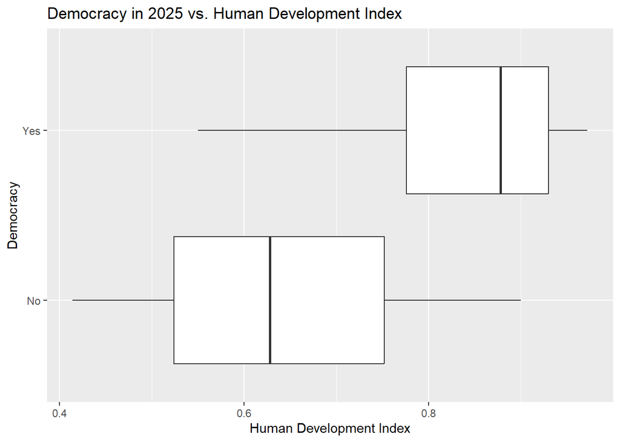

```r
FullData_2025|>
  ggplot(aes(x = HDI, y = Democracy)) +
  geom_boxplot() +
  labs(x = "Human Development Index",
       y = "Democracy",
       title = "Democracy in 2025 vs. Human Development Index")
```

This boxplot compares the Human Development Index (HDI) for democracies (Yes) and non-democracies (No). HDI is a score from 0 to 1, and a higher score means higher development. The democracy box sits far to the right of the non-democracy box. The median line for democracies is at about 0.88, and for non-democracies it is at about 0.63. The two boxes barely overlap. The democracy box runs from about 0.78 to 0.93, and the non-democracy box runs from about 0.52 to 0.75. The democracy box is narrower, so democracies are more alike in their scores. The non-democracy box is wider, so those countries vary more. The democracy median sits close to the right side of its box, and the lower whisker is long, reaching down to about 0.55. This shows that most democracies score high, with a few lower scorers. The non-democracy median is near the middle of its box, so the scores are spread more evenly, from about 0.41 to 0.90. There are no outlier dots in either group. Overall, the plot shows that democracies tend to have much higher human development than non-democracies.

### Stats and description

```r
Democracy_HDI_summary <- FullData_2025 |>
  group_by(Democracy) |>
  summarize(avg_hdi = mean(HDI),
            sd_hdi = sd(HDI),
            min_hdi = min(HDI),
            max_hdi = max(HDI),
            mdn_hdi = median(HDI),
            iqr_hdi = IQR(HDI),
            count = n())

Democracy_HDI_summary
```

```
# A tibble: 2 × 8
  Democracy avg_hdi sd_hdi min_hdi max_hdi mdn_hdi iqr_hdi count
  <fct>       <dbl>  <dbl>   <dbl>   <dbl>   <dbl>   <dbl> <int>
1 No          0.644  0.131   0.414   0.9     0.628   0.228    85
2 Yes         0.845  0.104   0.55    0.972   0.878   0.154    73
```

This table summarizes HDI for 73 democracies and 85 non-democracies. Democracies score higher. Their mean is about 0.845, compared with about 0.644 for non-democracies. The medians show the same gap, at about 0.878 for democracies and about 0.628 for non-democracies. That is a difference of about 0.25 in the median. In the democracy group, the mean is below the median, which points to left skew. A few lower scores pull the mean down. In the non-democracy group, the mean and median are close, so the values are more balanced. Democracies are also more consistent. Their standard deviation is about 0.104 and their IQR is about 0.154. For non-democracies, these are about 0.131 and 0.228. The ranges overlap. The lowest democracy scores about 0.550 and the highest scores about 0.972. The lowest non-democracy scores about 0.414 and the highest scores about 0.900. So the best non-democracy scores higher than the typical democracy, and the weakest democracy scores close to the typical non-democracy. Overall, democracies tend to have higher and more consistent human development. This shows a link, not a cause.The boxes barely overlap and there are no outliers, so HDI separates the groups best

## Variable 4: People in Poverty

### Graph and description

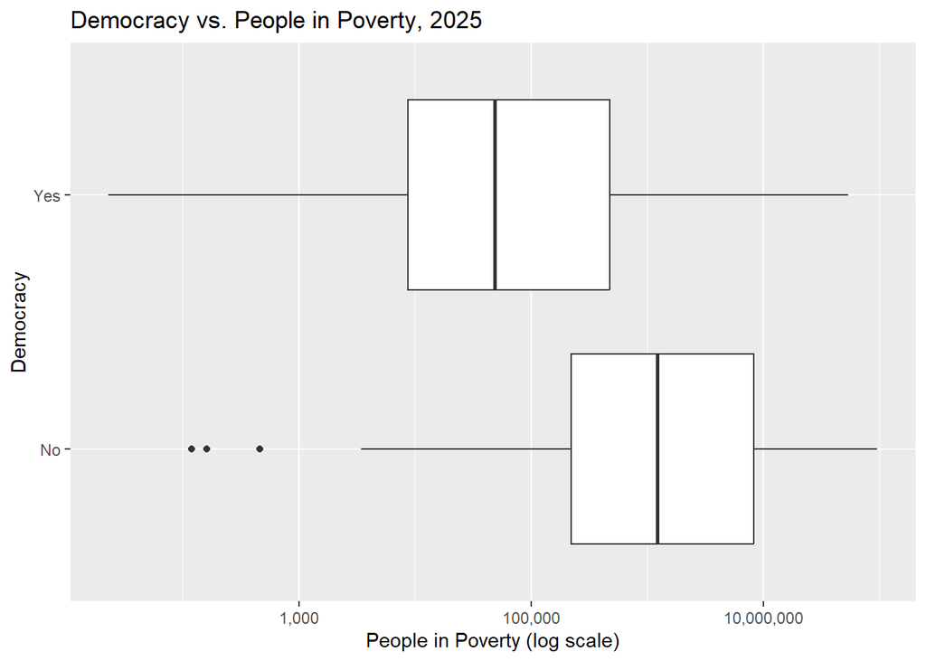

```r
FullData_2025 |>
  ggplot(aes(x = Poverty, y = Democracy)) +
  geom_boxplot() +
  scale_x_log10(labels = scales::comma) +
  labs(x = "People in Poverty (log scale)",
       y = "Democracy",
       title = "Democracy vs. People in Poverty, 2025")
```

### Stats and description

```r
Democracy_Poverty_summary <- FullData_2025 |>
  group_by(Democracy) |>
  summarize(avg_co2 = mean(Poverty),
            sd_poverty = sd(Poverty),
            min_poverty = min(Poverty),
            max_poverty = max(Poverty),
            mdn_poverty = median(Poverty),
            iqr_poverty = IQR(Poverty),
            count = n())

Democracy_Poverty_summary
```

```
# A tibble: 2 × 8
  Democracy  avg_co2 sd_poverty min_poverty max_poverty mdn_poverty iqr_poverty
  <fct>        <dbl>      <dbl>       <int>       <int>       <int>       <dbl>
1 No        7889325.  16367075.         119    95605313     1231006     8012347
2 Yes       1993225.   7158830.          23    54153959       48627      467645
# ℹ 1 more variable: count <int>
```

This table summarizes the number of people in poverty for 73 democracies and 85 non-democracies. Non-democracies have higher numbers. Their mean is about 7.9 million, compared with about 2.0 million for democracies. The medians show a much bigger gap. The median is about 1.23 million for non-democracies and only about 48,600 for democracies. So the typical non-democracy has about 25 times more people in poverty than the typical democracy. In both groups, the mean is far above the median. For non-democracies, it is about six times higher. For democracies, it is about forty times higher. A few very large countries pull the means up, so the median is a better measure of a typical country here. Non-democracies also vary more in the middle. Their IQR is about 8.0 million, compared with about 468,000 for democracies. But the standard deviation is large in both groups, about 16.4 million for non-democracies and about 7.2 million for democracies. In both cases, it is bigger than the mean, which is a sign of strong right skew. The ranges are wide. The smallest values are tiny, at 119 for non-democracies and 23 for democracies. The largest are about 95.6 million for non-democracies and about 54.2 million for democracies. Overall, non-democracies have more people in poverty, but a few huge countries drive the averages in both groups. This is a link, not a cause.

## Variable 5: Region

### Graph and description

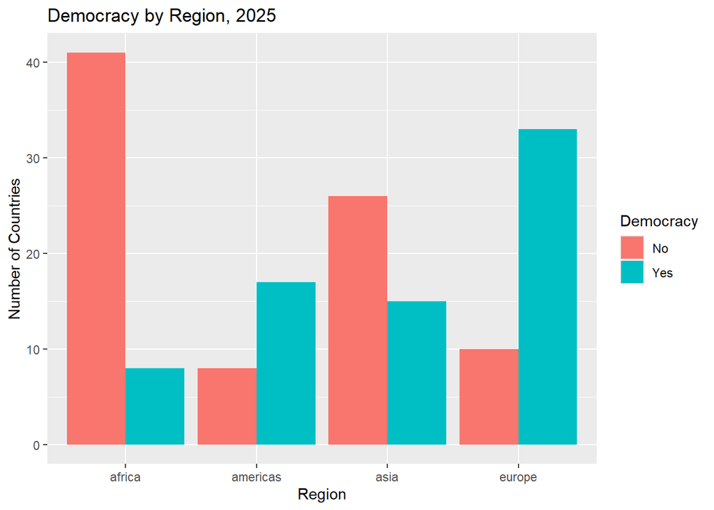

```r
FullData_2025 |>
  ggplot(aes(x = world_4region, fill = Democracy)) +
  geom_bar(position = "dodge") +
  labs(x = "Region",
       y = "Number of Countries",
       fill = "Democracy",
       title = "Democracy by Region, 2025")
```

```r
names(FullData_2025)
```

```
[1] "geo"           "name"          "Democracy"     "CO2"
[5] "GDP"           "HDI"           "Poverty"       "world_4region"
```

### Stats and description

```r
region_democracy_summary <- FullData_2025 |>
  group_by(world_4region, Democracy) |>
  summarize(count = n()) |>
  mutate(percent = round(count / sum(count) * 100, 1))
```

```
`summarise()` has regrouped the output.
ℹ Summaries were computed grouped by world_4region and Democracy.
ℹ Output is grouped by world_4region.
ℹ Use `summarise(.groups = "drop_last")` to silence this message.
ℹ Use `summarise(.by = c(world_4region, Democracy))` for per-operation grouping
  (`?dplyr::dplyr_by`) instead.
```

```r
region_democracy_summary
```

```
# A tibble: 8 × 4
# Groups:   world_4region [4]
  world_4region Democracy count percent
  <chr>         <fct>     <int>   <dbl>
1 africa        No           41    83.7
2 africa        Yes           8    16.3
3 americas      No            8    32
4 americas      Yes          17    68
5 asia          No           26    63.4
6 asia          Yes          15    36.6
7 europe        No           10    23.3
8 europe        Yes          33    76.7
```

This table shows how many countries in each world region are democracies and non-democracies. There are 158 countries in all, with 73 democracies and 85 non-democracies. Africa has the most non-democracies, with 41, and only 8 democracies. That means only about 16 percent of its 49 countries are democracies. Europe is the opposite. It has 33 democracies and 10 non-democracies, so about 77 percent of its 43 countries are democracies. The Americas also lean toward democracy, with 17 democracies and 8 non-democracies, which is 68 percent of 25 countries. Asia is the most mixed, with 26 non-democracies and 15 democracies, so about 37 percent of its 41 countries are democracies. Overall, democracy is most common in Europe and the Americas, and least common in Africa.

## Which variable for single variable models?

From your exploratory data analysis, which variable will you use for the single variable models? Why?

## kNN classification

```r
#Splitting Data

#setting seed for reproducability
set.seed(2005)

#making split
FullData_2025_parts <- FullData_2025 |>
  initial_split(prop = 0.8)

#getting training data
FullData_2025_train <- FullData_2025_parts |>
  training()

#getting testing data
FullData_2025_test <- FullData_2025_parts |>
  testing()

#checking sizes could do seperately and avoid list
list(FullData_2025_train, FullData_2025_test) |>
  map_int(nrow)
```

```
[1] 126  32
```

```r
#Cross Validation Folds
folds <- vfold_cv(FullData_2025_train, v = 5) #this makes the folds
folds
```

```
#  5-fold cross-validation
# A tibble: 5 × 2
  splits           id
  <list>           <chr>
1 <split [100/26]> Fold1
2 <split [101/25]> Fold2
3 <split [101/25]> Fold3
4 <split [101/25]> Fold4
5 <split [101/25]> Fold5
```

```r
#Setting classification metrics
classification_metrics <- metric_set(accuracy, yardstick::sensitivity,yardstick::specificity )
```

### Single variable model

Make a kNN model using your best predictor variable

```r
#Recipe
knn_recipe_single <- recipe(Democracy ~ HDI, data = FullData_2025_train) |>
  step_string2factor(all_nominal_predictors()) |> #From ai
  step_normalize(all_numeric_predictors())|>
  step_dummy(all_nominal_predictors())

#Specification
knn_spec_single <- nearest_neighbor(neighbors=tune(),  weight_func = "rectangular") |>
  set_engine("kknn")|>
  set_mode("classification")

#Workflow
knn_wf_single<-workflow()|>
  add_recipe(knn_recipe_single)|>
  add_model(knn_spec_single)
```

#### Model tuning to find k

```r
#Tuning Grid
knn_grid_single <- tibble(neighbors = seq(from=1, to=41, by=2))

knn_cv_single <- tune_grid(
  knn_wf_single,
  resamples = folds,
  grid = knn_grid_single,
  metrics = classification_metrics
)
cv_metrics_knn_single<-collect_metrics(knn_cv_single)
cv_metrics_knn_single
```

```
# A tibble: 63 × 7
   neighbors .metric     .estimator  mean     n std_err .config
       <dbl> <chr>       <chr>      <dbl> <int>   <dbl> <chr>
 1         1 accuracy    binary     0.723     5  0.0418 pre0_mod01_post0
 2         1 sensitivity binary     0.760     5  0.0576 pre0_mod01_post0
 3         1 specificity binary     0.691     5  0.0471 pre0_mod01_post0
 4         3 accuracy    binary     0.667     5  0.0560 pre0_mod02_post0
 5         3 sensitivity binary     0.684     5  0.0744 pre0_mod02_post0
 6         3 specificity binary     0.658     5  0.0746 pre0_mod02_post0
 7         5 accuracy    binary     0.699     5  0.0590 pre0_mod03_post0
 8         5 sensitivity binary     0.706     5  0.0828 pre0_mod03_post0
 9         5 specificity binary     0.709     5  0.0631 pre0_mod03_post0
10         7 accuracy    binary     0.683     5  0.0414 pre0_mod04_post0
# ℹ 53 more rows
```

```r
#Grabbing best k
best_k_single <- select_best(knn_cv_single, metric = "accuracy")
best_k_single
```

```
# A tibble: 1 × 2
  neighbors .config
      <dbl> <chr>
1        25 pre0_mod13_post0
```

#### Model for best k

```r
#Specification for best k
knn_spec_single_best <- nearest_neighbor(neighbors=25, weight_func = "rectangular") |>
  set_engine("kknn")|>
  set_mode("classification")

#Workflow for best k
knn_wf_single_best<-workflow()|>
  add_recipe(knn_recipe_single)|>
  add_model(knn_spec_single_best)

#Fitting model
knn_fit_single <-
  knn_wf_single_best |>
  fit(data = FullData_2025_train)
knn_fit_single
```

```
══ Workflow [trained] ══════════════════════════════════════════════════════════
Preprocessor: Recipe
Model: nearest_neighbor()

── Preprocessor ────────────────────────────────────────────────────────────────
3 Recipe Steps

• step_string2factor()
• step_normalize()
• step_dummy()

── Model ───────────────────────────────────────────────────────────────────────

Call:
kknn::train.kknn(formula = ..y ~ ., data = data, ks = min_rows(25,     data, 5), kernel = ~"rectangular")

Type of response variable: nominal
Minimal misclassification: 0.2460317
Best kernel: rectangular
Best k: 25
```

#### Model evaluation-accuracy, cv for overfitting

```r
#Accuracy and overfitting assessment

#Accuracy
test_results_knn_single <- augment(knn_fit_single, new_data = FullData_2025_test)

test_knn_metrics_single<-accuracy(test_results_knn_single, truth = Democracy, estimate = .pred_class)

test_knn_metrics_single
```

```
# A tibble: 1 × 3
  .metric  .estimator .estimate
  <chr>    <chr>          <dbl>
1 accuracy binary         0.781
```

```r
#CV overfitting check
cv_best_k_single=cv_metrics_knn_single|>
  filter(neighbors==25)

combined_metrics_knn_single <- test_knn_metrics_single |>
  select(.metric, knn_estimate=.estimate) |>
  left_join(
    cv_best_k_single |> select(.metric, cvknn_estimate = mean),
    by = ".metric"
  ) |>
  rename(
    `Test Set` = knn_estimate,
    `CV Mean`        = cvknn_estimate
  )

combined_metrics_knn_single
```

```
# A tibble: 1 × 3
  .metric  `Test Set` `CV Mean`
  <chr>         <dbl>     <dbl>
1 accuracy      0.781     0.771
```

### All variable model

Make a kNN model using all your predictor variables

```r
#Recipe: From lecture 14 + ai
knn_recipe_all <- recipe(Democracy ~ ., data = FullData_2025_train) |>
  update_role(geo, name, new_role = "ID") |> #From ai
  step_string2factor(all_nominal_predictors()) |> #From ai
  step_normalize(all_numeric_predictors())|>
  step_dummy(all_nominal_predictors())

#Specification: From lecture 14
knn_spec_all <- nearest_neighbor(neighbors=tune(),  weight_func = "rectangular") |>
  set_engine("kknn")|>
  set_mode("classification")

#Workflow: From elcture 14
knn_wf_all<-workflow()|>
  add_recipe(knn_recipe_all)|>
  add_model(knn_spec_all)
```

#### Model tuning to find k using cv.

```r
#Tuning Grid
knn_grid_all <- tibble(neighbors = seq(from=1, to=41, by=2))

knn_cv_all <- tune_grid(
  knn_wf_all,
  resamples = folds,
  grid = knn_grid_all,
  metrics = classification_metrics
)
cv_metrics_knn_all<-collect_metrics(knn_cv_all)
cv_metrics_knn_all
```

```
# A tibble: 63 × 7
   neighbors .metric     .estimator  mean     n std_err .config
       <dbl> <chr>       <chr>      <dbl> <int>   <dbl> <chr>
 1         1 accuracy    binary     0.738     5  0.0210 pre0_mod01_post0
 2         1 sensitivity binary     0.751     5  0.0402 pre0_mod01_post0
 3         1 specificity binary     0.738     5  0.0532 pre0_mod01_post0
 4         3 accuracy    binary     0.739     5  0.0247 pre0_mod02_post0
 5         3 sensitivity binary     0.844     5  0.0497 pre0_mod02_post0
 6         3 specificity binary     0.643     5  0.0694 pre0_mod02_post0
 7         5 accuracy    binary     0.739     5  0.0278 pre0_mod03_post0
 8         5 sensitivity binary     0.859     5  0.0550 pre0_mod03_post0
 9         5 specificity binary     0.628     5  0.0765 pre0_mod03_post0
10         7 accuracy    binary     0.771     5  0.0444 pre0_mod04_post0
# ℹ 53 more rows
```

```r
#Grabbing best k: From lecture 14
best_k_all <- select_best(knn_cv_all, metric = "accuracy")
best_k_all
```

```
# A tibble: 1 × 2
  neighbors .config
      <dbl> <chr>
1         7 pre0_mod04_post0
```

#### Model for best k

```r
#Specification for best k
knn_spec_all_best <- nearest_neighbor(neighbors=7,  weight_func = "rectangular") |>
  set_engine("kknn")|>
  set_mode("classification")

#Workflow for best k
knn_wf_all_best<-workflow()|>
  add_recipe(knn_recipe_all)|>
  add_model(knn_spec_all_best)

#Fitting model
knn_fit_all <-
  knn_wf_all_best |>
  fit(data = FullData_2025_train)
knn_fit_all
```

```
══ Workflow [trained] ══════════════════════════════════════════════════════════
Preprocessor: Recipe
Model: nearest_neighbor()

── Preprocessor ────────────────────────────────────────────────────────────────
3 Recipe Steps

• step_string2factor()
• step_normalize()
• step_dummy()

── Model ───────────────────────────────────────────────────────────────────────

Call:
kknn::train.kknn(formula = ..y ~ ., data = data, ks = min_rows(7,     data, 5), kernel = ~"rectangular")

Type of response variable: nominal
Minimal misclassification: 0.2380952
Best kernel: rectangular
Best k: 7
```

#### Model evaluation-accuracy, cv for overfitting

```r
#Accuracy and overfitting assessment

#Accuracy
test_results_knn_all <- augment(knn_fit_all, new_data = FullData_2025_test)

test_knn_metrics_all<-accuracy(test_results_knn_all, truth = Democracy, estimate = .pred_class)

test_knn_metrics_all
```

```
# A tibble: 1 × 3
  .metric  .estimator .estimate
  <chr>    <chr>          <dbl>
1 accuracy binary         0.875
```

```r
#CV overfitting check
cv_best_k_all=cv_metrics_knn_all|>
  filter(neighbors==7)

combined_metrics_knn_all <- test_knn_metrics_all |>
  select(.metric, knn_estimate=.estimate) |>
  left_join(
    cv_best_k_all |> select(.metric, cvknn_estimate = mean),
    by = ".metric"
  ) |>
  rename(
    `Test Set` = knn_estimate,
    `CV Mean`        = cvknn_estimate
  )

combined_metrics_knn_all
```

```
# A tibble: 1 × 3
  .metric  `Test Set` `CV Mean`
  <chr>         <dbl>     <dbl>
1 accuracy      0.875     0.771
```

### Which model was best?

Of your two kNN models which performed the best? Why? If it was the multivariate model was it worth the trade off of complexity? Why?

The multivariate knn classification model performed the best because it had an accuracy of 87.5% on the test data. It was worth the trade off of complexity in this case because the single variable model only had an accuracy of 78.1% on the test data. There is a ~10% discrepancy between the multivariate test data accuracy and the cross validation estimate, but this does not indicate that the model is overfitting since the test data accuracy is higher than the cross validation estimate.

## Logistic Regression

### Single variable model

Make a logistic regression model using your best predictor variable

#### Model

```r
#recipe
log_rec<-
  recipe(Democracy~ HDI, data=FullData_2025_train)

#setting engine
logit_mod <-
  logistic_reg()|>
  set_engine("glm")|>
  set_mode("classification")

# workflow
glm_workflow <-
  workflow() |>
  add_recipe(log_rec)|>
  add_model(logit_mod)

# fitting model
dem_fit <-
  glm_workflow |>
  fit(data = FullData_2025_train)
```

#### Equation and Graph of model

*Equation:* $log(\frac{\hat{p}}{1-\hat{p}})=-10.09596+13.37363x_{HDI}$

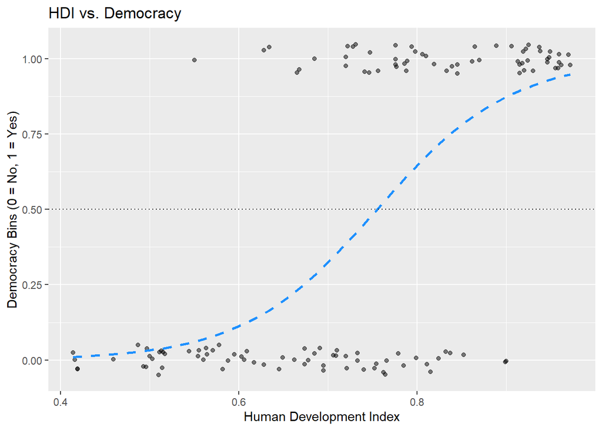

```r
# GRAPH
FullData_bin <- FullData_2025_train |>
  mutate(bin_dem=if_else(Democracy=="Yes",1,0))

ggplot(FullData_bin, aes(x = HDI, y = bin_dem)) +
  geom_point(
    position = position_jitter(width = 0, height = 0.05),
    alpha = 0.5
  ) +
  geom_smooth(
    method = "glm", method.args = list(family = "binomial"),
    color = "dodgerblue", lty = 2, se = FALSE
  ) +
  geom_hline(aes(yintercept = 0.5), linetype = 3)+
   labs(y="Democracy Bins (0 = No, 1 = Yes)",x="Human Development Index", title="HDI vs. Democracy")
```

#### Model evaluation-p-values, accuracy, cv for overfitting, roc, auc

```r
# p-value
tidy(dem_fit)
```

```
# A tibble: 2 × 5
  term        estimate std.error statistic      p.value
  <chr>          <dbl>     <dbl>     <dbl>        <dbl>
1 (Intercept)    -10.1      1.78     -5.66 0.0000000155
2 HDI             13.4      2.34      5.71 0.0000000113
```

```r
# Accuracy
test_results <- augment(dem_fit, new_data = FullData_2025_test) # adding original data

test_metric<-test_results|>
  accuracy(truth = Democracy, estimate = .pred_class)
test_metric
```

```
# A tibble: 1 × 3
  .metric  .estimator .estimate
  <chr>    <chr>          <dbl>
1 accuracy binary         0.812
```

```r
# CV for Overfitting
set.seed(2005)
folds <- vfold_cv(FullData_2025_train, v = 5) #this makes the folds
class_met=metric_set(accuracy)

glm_dem_cv <-
  glm_workflow |>
  fit_resamples(resamples = folds,
    metrics = class_met)

cv_metrics<-collect_metrics(glm_dem_cv)
cv_metrics
```

```
# A tibble: 1 × 6
  .metric  .estimator  mean     n std_err .config
  <chr>    <chr>      <dbl> <int>   <dbl> <chr>
1 accuracy binary     0.778     5  0.0460 pre0_mod0_post0
```

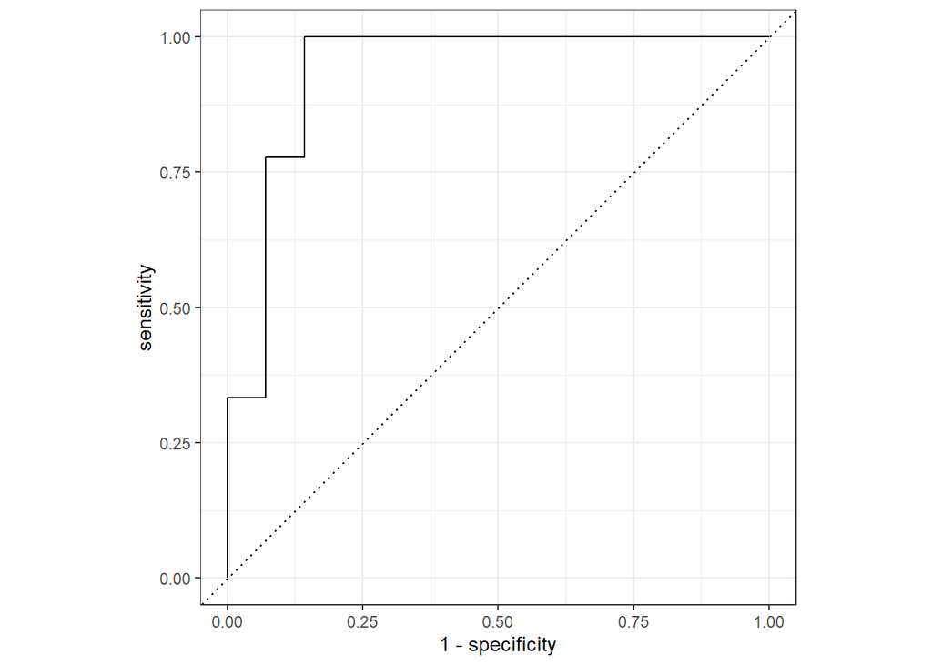

```r
# ROC & AUC
autoplot(roc_curve(test_results, truth = Democracy, `.pred_No`)) # ROC Graph
```

```r
roc_auc(test_results, truth = Democracy, `.pred_No`) # AUC
```

```
# A tibble: 1 × 3
  .metric .estimator .estimate
  <chr>   <chr>          <dbl>
1 roc_auc binary         0.937
```

**p-value:**

$p-value=1.129828e-08$

Since the p-value of the `HDI` very small (threshold: $p<=0.05$), we can say that the slope is significantly different from 0. Therefore it is *statistically significant*.

**Accuracy:** 0.8125

This tells us that our current model correctly classified approximately 81.25% of cases in the test set for our response variable (Democracy).

**CV for Overfitting:**

From our CV, we got 0.7781538. We can say that it is unlikely that our model overfit as 0.7781538 is reasonably close to 0.8125.

**ROC & AUC:**

$AUC=0.9365079$

We can evaluate the quality of the ROC from the area under the curve (AUC). From the graph we can see that the ROC is pretty good as it is above the 0.5 threshold which means the model can effectively discriminate between the `democracy` and `no democracy` classes and overall performs better than a 50/50 guess. The AUC is the area under the curve and is approximately 0.94 which tells us that the performance of the model is quite strong since it is close to AUC=1.0 which is a model that makes perfect predictions.

### All variable model

Make a logistic regression model using all your predictor variables

#### Model

```r
# Create list of only predictor variables
predictors <- colnames(FullData_2025)[4:8]

#recipe
log_rec<-
  recipe(as.formula(paste("Democracy ~", paste(predictors, collapse = " + "))),
         data=FullData_2025_train)

#setting engine
logit_mod <-
  logistic_reg()|>
  set_engine("glm")|>
  set_mode("classification")

# workflow
glm_workflow2 <-
  workflow() |>
  add_recipe(log_rec)|>
  add_model(logit_mod)

# fitting model
demMulti_fit <-
  glm_workflow2 |>
  fit(data = FullData_2025_train)
```

#### Equation of model

*Equation:* $log(\frac{\hat{p}}{1-\hat{p}})=-12.59693+17.45064x_{HDI}+0.000007621737 x_{GDP}+0.00000002082547 x_{Poverty}+0.0006021593x_{CO2}-0.04838529x_{americas}-1.787578x_{asia}-1.825651x_{europe}$

#### Model evaluation-p-values, accuracy, cv for overfitting, roc, auc

```r
# p-value
tidy(demMulti_fit)
```

```
# A tibble: 8 × 5
  term                  estimate    std.error statistic  p.value
  <chr>                    <dbl>        <dbl>     <dbl>    <dbl>
1 (Intercept)           -1.26e+1 3.52           -3.58   0.000339
2 CO2                    6.02e-4 0.000797        0.756  0.450
3 GDP                    7.62e-6 0.0000214       0.356  0.722
4 HDI                    1.75e+1 5.40            3.23   0.00122
5 Poverty                2.08e-8 0.0000000231    0.902  0.367
6 world_4regionamericas -4.84e-2 0.790          -0.0613 0.951
7 world_4regionasia     -1.79e+0 0.858          -2.08   0.0373
8 world_4regioneurope   -1.83e+0 1.03           -1.77   0.0776
```

```r
# Accuracy
test_results <- augment(demMulti_fit, new_data = FullData_2025_test) # adding original data

test_metric<-test_results|>
  accuracy(truth = Democracy, estimate = .pred_class)
test_metric
```

```
# A tibble: 1 × 3
  .metric  .estimator .estimate
  <chr>    <chr>          <dbl>
1 accuracy binary         0.812
```

```r
# CV for Overfitting
set.seed(2005)
folds <- vfold_cv(FullData_2025_train, v = 5) #this makes the folds
class_met=metric_set(accuracy)

glm_demMulti_cv <-
  glm_workflow2 |>
  fit_resamples(resamples = folds,
    metrics = class_met)

cv_metrics<-collect_metrics(glm_demMulti_cv)
cv_metrics
```

```
# A tibble: 1 × 6
  .metric  .estimator  mean     n std_err .config
  <chr>    <chr>      <dbl> <int>   <dbl> <chr>
1 accuracy binary     0.746     5  0.0346 pre0_mod0_post0
```

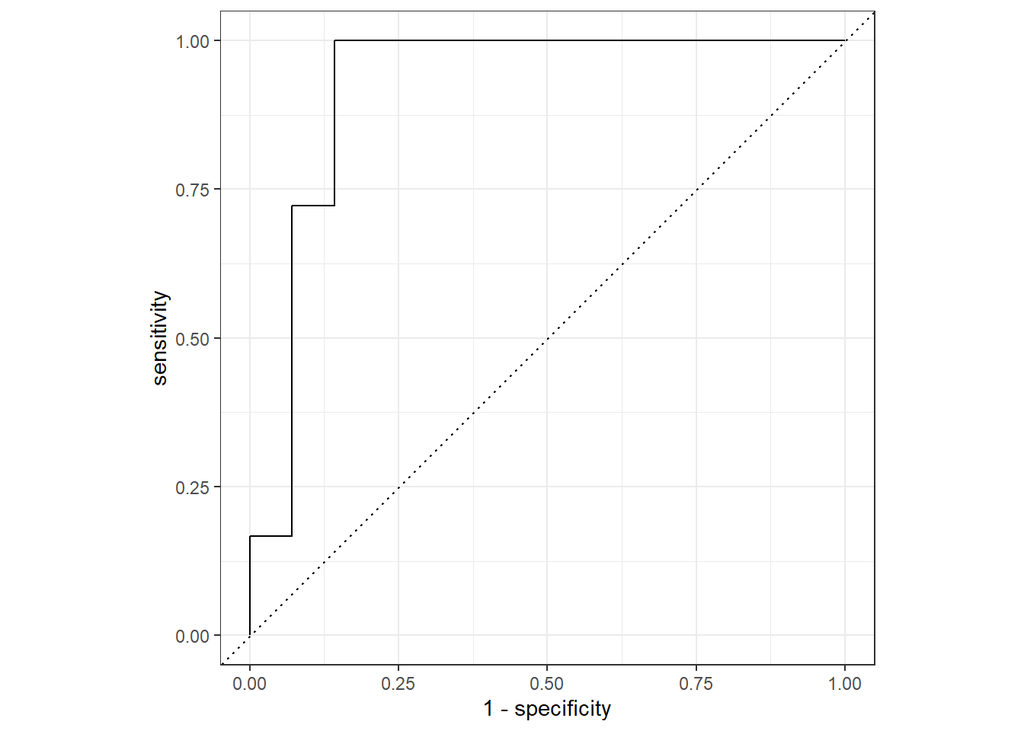

```r
# ROC & AUC
autoplot(roc_curve(test_results, truth = Democracy, `.pred_No`)) # ROC Graph
```

```r
roc_auc(test_results, truth = Democracy, `.pred_No`) # AUC
```

```
# A tibble: 1 × 3
  .metric .estimator .estimate
  <chr>   <chr>          <dbl>
1 roc_auc binary         0.921
```

**p-value:**

Since the p-value of the model is very small (threshold: $p<=0.05$), we can say that there is at least one predictor variable that is significantly different from 0. Therefore it is *statistically significant*.

*CO2:* $p-value=0.4498042290$

Since the p-value of the `CO2` is not considered small (threshold: $p<=0.05$), we *cannot* say that the slope is significantly different from 0. Therefore it is NOT *statistically significant*.

*GDP:* $0.7221149867$

Since the p-value of the `GDP` is not considered small (threshold: $p<=0.05$), we *cannot* say that the slope is significantly different from 0. Therefore it is NOT *statistically significant*.

*HDI:* $p-value=0.0012223916$

Since the p-value of the `HDI` very small (threshold: $p<=0.05$), we can say that the slope is significantly different from 0. Therefore it is *statistically significant*.

*Poverty:* $p-value=0.3670983647$

Since the p-value of the `Poverty` is not considered small (threshold: $p<=0.05$), we *cannot* say that the slope is significantly different from 0. Therefore it is NOT *statistically significant*.

*Regions: NOTE-* As long as one of the categorical indicators has slope significantly different from zero, then we include in the model.

*americas:* $p-value=0.9511431885$

Since the p-value of the `americas` region is not considered small (threshold: $p<=0.05$), we *cannot* say that the slope for `americas` region vs `africa` region is significantly different from zero.

*asia:* $p-value=0.0372680967$

Since the p-value of the `asia` region is very small (threshold: $p<=0.05$), we can say that the slope for `asia` region vs `africa` region is significantly different from zero.

*europe:* $p-value=0.0775613480$

Since the p-value of the `europe` region is not considered small (threshold: $p<=0.05$), we *cannot* say that the slope for `europe` region vs `africa` region is significantly different from zero.

**Accuracy:** 0.8125

This tells us that our current model correctly classified approximately 81.25% of cases in the test set for our response variable (Democracy).

**ROC & AUC:**

$AUC=0.9206349$

We can evaluate the quality of the ROC from the area under the curve (AUC). From the graph we can see that the ROC is pretty good as it is above the 0.5 threshold which means the model can effectively discriminate between the `democracy` and `no democracy` classes and overall performs better than a 50/50 guess. The AUC is the area under the curve and is approximately 0.92 which tells us that the performance of the model is quite strong since it is close to AUC=1.0 which is a model that makes perfect predictions.

### Which model was best?

Of your two logistic regression models which performed the best? Why? If it was the multivariate model was it worth the trade off of complexity? Why?

The *single variable* logistic regression model performed the best overall. We can see that both models held the same testing accuracy (81.25%), but the Cross Validation accuracy for the single variable model (77.81%) is higher than that of the multivariable model (74.62%). This tells us that both models where fairly comparable in their accuracy performance; however, the single variable model performed better when it came to how well the model was able to generalize to unseen data from the CV folds.

On top of that, the AUC of the single variable model (0.94) is also higher than the AUC for the multivariable model (0.92). This is important since this metric tells us the model quality. Since the single variable model has a higher AUC, we can say that the model makes stronger predictions in comparison to the multivariable model.

Therefore, the single variable logistic regression model performed the best.

## Best model

Which model would you recommend the lab use? Why? Are there trade-offs between interpretability and model metrics?

Overall, even with some of the trade-offs with the multivariable KNN classification model, we still recommend this model to be used in the lab. Its metrics are the best overall, and demonstrate that it is an effective model for the purposes of predicting the response variable (Democracy).

## Your question

You will write your own question about the data, create a data visualization that can help answer your question, and write an answer to your question. The question/visualization should explore the relationship between at least 2 of the variables in the dataset. Be sure you include both the question and the answer to your question based on the visualization you have created. It should be a different question than last mini-project.

**QUESTION:** How does average log GDP differ between democratic and nondemocratic countries across world regions?

```r
FullData_viz<- FullData_2025|>
  mutate(log_gdp=log10(GDP)) # log GDP for scaling

# Calculate Average log GDP for each region and Democracy Group
GDP_summary <- FullData_viz |>
  group_by(world_4region, Democracy) |>
  summarise(avg_log_gdp = mean(log_gdp))
```

```
`summarise()` has regrouped the output.
ℹ Summaries were computed grouped by world_4region and Democracy.
ℹ Output is grouped by world_4region.
ℹ Use `summarise(.groups = "drop_last")` to silence this message.
ℹ Use `summarise(.by = c(world_4region, Democracy))` for per-operation grouping
  (`?dplyr::dplyr_by`) instead.
```

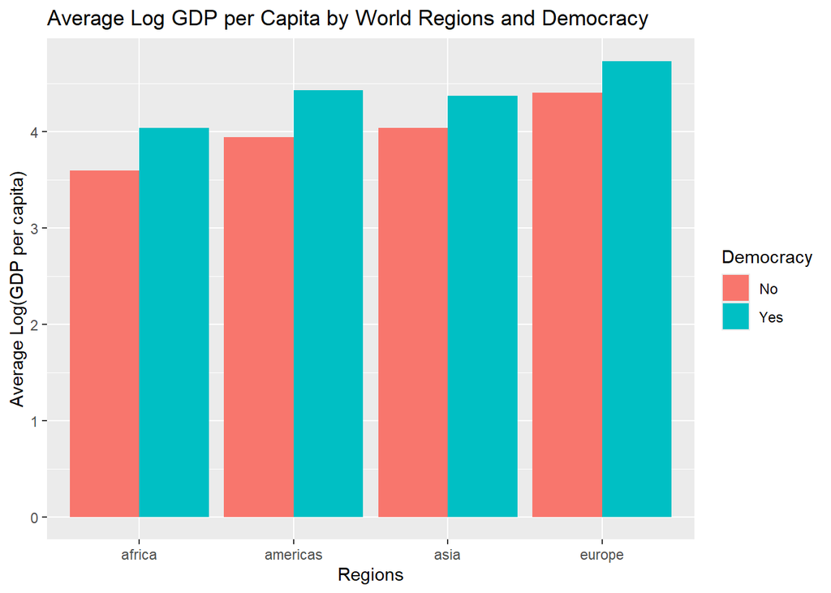

```r
# Create grouped bar chart
GDP_summary|>
  ggplot(aes(x = world_4region, y = avg_log_gdp, fill = Democracy)) +
  geom_col(position = "dodge") +
  labs(
    x = "Regions",
    y = "Average Log(GDP per capita)",
    title = "Average Log GDP per Capita by World Regions and Democracy"
  )
```

**ANSWER:** From the above graph, we can see that democracies tend to have higher average log GDP whereas countries that do NOT have democracy generally have a lower average log GDP in comparison across all four regions. This graph also allows us to look into the relationship between the regions themselves and their log GDP. We can see that Europe and the Americas both have higher average Log GDP for democratic countries compared to countries in Asia and Africa. On the other hand, Europe and Asia have higher average log GDP for nondemocratic countries compared to countries in the Americas and Africa. Europe has the highest average log GDP per capita for both countries with and without democracy compared to all other regions while Africa has the lowest average log GDP per capita. Both the Americas and Asia fall in the center with the regions being very comparable in their respective average log GDP per amounts. Overall, this graph gives us much insight into the original question as we are able to explore relationships and differences of the average log GDP between democratic and nondemocratic countries across world regions.